# Response to Medication Use in HF Patients

[Baker Bioinformatics](https://intranet.baker.edu.au/research-resources/platform-technologies/bioinformatics-program/) - 15 November 2021

# 1 Study Design

#### **Objective**

Here we use the UK Biobank to look at response to medication us in participants with Heart Failure (HF).

**Schematic of the study design**

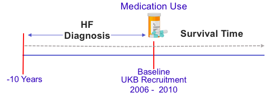

Schematic of the study design

# 2 Study Plan

#### **Study Plan**

1. Get HF Individuals (Self Reported and ICD10 codes)
2. Get Medication Use (Names for Each Class and match with UKB Medication code)
   3. Survival Information (Names for Each Class and match with UKB Medication code)

## 2.1 HF selection

Schematic of Heart Failure Sample Selection. Heart Failure was defined using the inclusion/exclusion criterion previously published in Shah et al (2020) https://www.nature.com/articles/s41467-019-13690-5

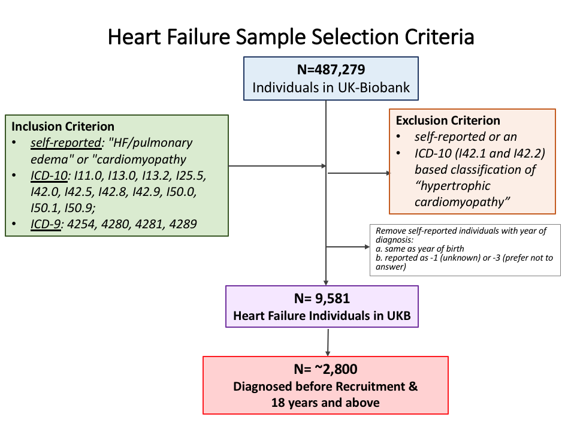

## 2.2 HF ICD10 Codes

[figure not shown]

# 3 Medication

#### **Medication Use for HF Individuals!**

Self-Reported Medication data-field 20003 was used for medications listed below:

The following medications were looked at: ACE inhibitors, alpha blockers, angiotensin II receptor blockers, beta blockers, calcium channel blockers and diuretics .

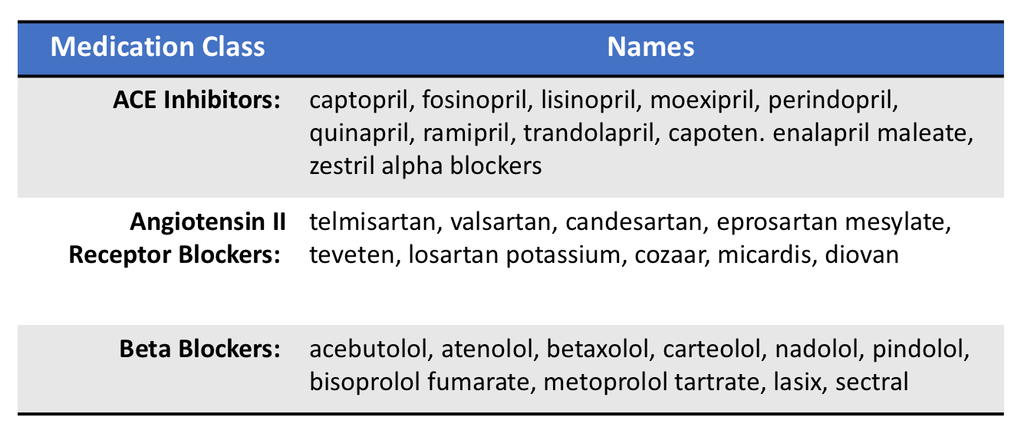

## 3.1 Matching Medication codes

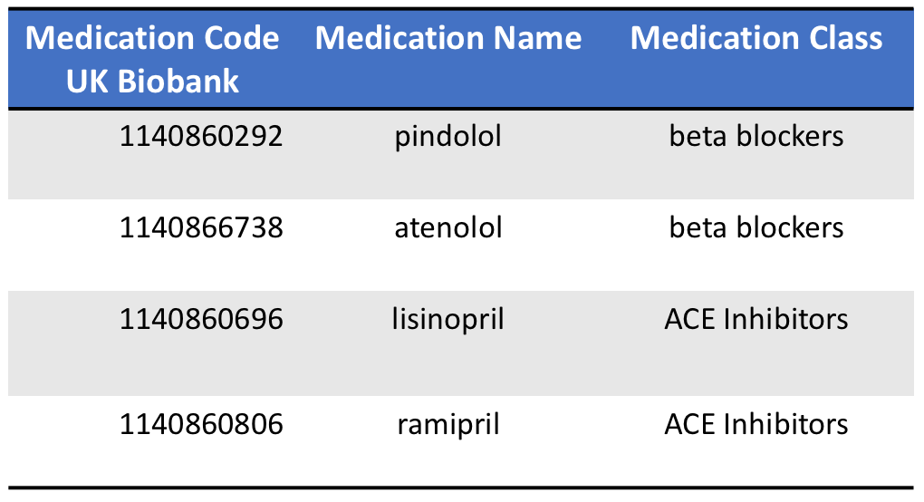

## 3.2 Medication Class Use and Frequency

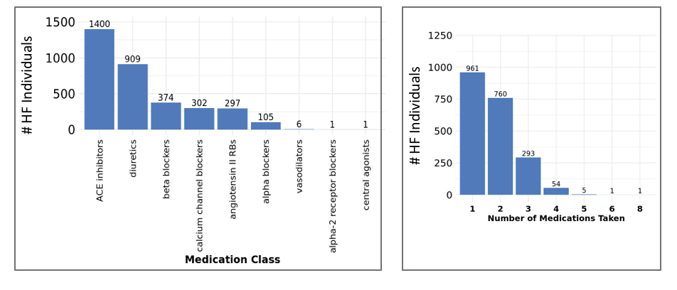

# 4 Survival Analysis

## 4.1 Death Information

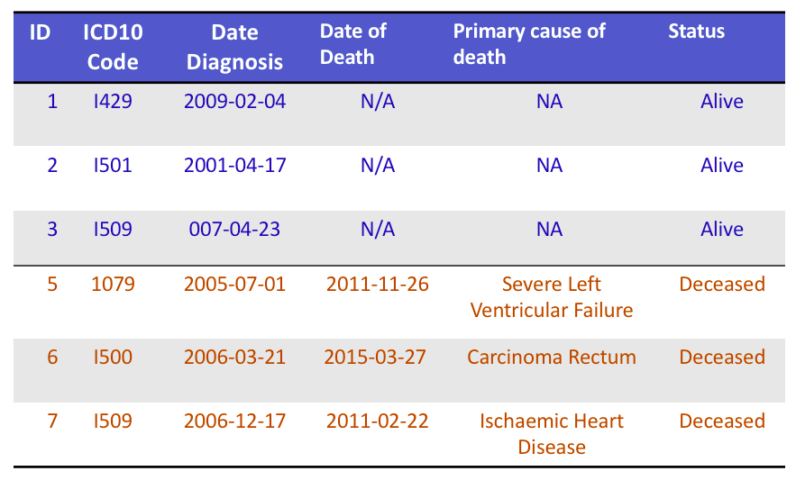

## 4.2 Survival Analysis

#### **KM Survival Curve - Stratified by Medication Use!**

Kaplan-Meier survival curves stratified by Medication Frequency, Not Adjusted for any Covariates.

The “number at risk”" table for medication use is provided below the survival curve.

Medication Frequency means take either no medication (FreqMed=0); 1 medication type (FreqMed=1); 2 or more medication type (FreqMed = 2+).

Survival rates are higher in HF for those who take No Medication or 1 particular type of medication.

Does this people who take multiple medication (2 or more types) are more sicker or have been taking medication way before HF diagnosis????.

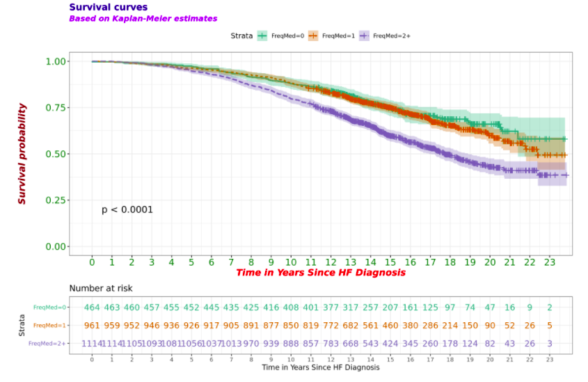

A work by [Baker Bioinformatics](https://intranet.baker.edu.au/research-resources/platform-technologies/bioinformatics-program/)

*bioinformatics@baker.edu.au*